# Final Presentation

Stephen Trippy

5/2/2021

# Introduction

Introducing Yelp Fusion! This is an API with excellent documentation that allows access to almost any restaurant in the world!

Not without a catch:

- limits on the number of restaurants/request (1000)
- search algorithm is a black box

In cleaning and manipulating the data, hope to answer the following question:

- Does the average price of restaurants in a given zip code correlate with median income in the zip code, and can we infer why or why not?

Along the way, we’ll learn more about the Yelp API, and how to access APIs in general!

## Libraries! I need a few:

Won’t go over all of these, but notice “devtools” and “choroplethrZip”

```r
library("dplyr")
library("jsonlite")
library("httr")
library("readxl")
library("tidyr")
library("ggplot2")
library("devtools")
library("RCurl")
library("sf")

#install_github('arilamstein/choroplethrZip@v1.5.0')
library("choroplethrZip")
```

# Part 1: Building the Dataset

## Creating vector of Harris County Zip codes

Allows us to query by zip code

Zip code data was copied from https://www.zillow.com/browse/homes/tx/harris-county/ and pasted into a .csv file

Before doing this, we must make sure that the csv file is in our working directory

```r
harris_zips <- read.csv('harris_zipcodes.csv')
```

## Reading in Census Data

Next, we read in census data (2006 - 2010)

- unfortunately not current, but can make assumption that income hasn’t changed
- Added benefit of using census data: gives us *only valid* zip codes. *won’t break query process*

Census data was sourced from: https://www.psc.isr.umich.edu/dis/census/Features/tract2zip/

```r
#read the demographic data in. cells with no data are marked with a '.'

zip_demographic_data <- read_excel('zipcode_census_data.xlsx', sheet = 'nation', na = ".") %>%
  rename(zip_code = Zip)
harris_data_by_zip <- inner_join(harris_zips, zip_demographic_data, by = 'zip_code')

#Some of the zip codes in harris_zips had no demographic data, so i decided to
#inner_join.
#I could left join though, if I really felt like keeping all of the restaurant data
#from these zip codes
```

Let’s play around with the data we’ve just gotten

```r
harris_data_by_zip %>%
  arrange(desc(Median)) %>%
  head(10)
```

```
##    zip_code    Median     Mean   Pop
## 1     77401 153648.53 204877.7 17491
## 2     77094 148245.14 170986.5  8498
## 3     77005 141928.87 209889.7 23151
## 4     77059 133259.02 151170.6 16949
## 5     77024 132759.43 210545.4 34775
## 6     77345 123437.99 154831.6 26122
## 7     77079 102246.16 131198.1 31280
## 8     77450 101498.39 121174.3 71889
## 9     77379 100527.40 120940.0 70544
## 10    77546  95641.87 109594.8 47636
```

```r
#small sample of the 10 wealthiest zip codes by median income in Harris county.
#Neat!
```

## Preparing the URI

We now prepare the address we’ll be using to query. I have a personal API key, which is stored in a separate file. If you wish to reproduce this code, you’ll need to file a Fusion application and provide your own “yelp_api_key.R” file

The format of this file should be:

client_ID <- “Your_Application_ID” yelp_key <- “Your_Yelp_Key”

```r
#Loading the API key from a separate file
source("yelp_api_key.R") #allows yelp_key to be available
#info in order to make GET request, using API key as a header
base_uri <- "https://api.yelp.com/v3"
endpoint <- "/businesses/search"
search_uri <- paste0(base_uri, endpoint)
```

## Unleashing the Beast

Now, we prepare to query.

Plan is to cycle through every zip code in Harris county, pull max zip codes

2 Problems with approach:

- 1. The yelp api doesn’t return data the way I’d like it to: other restaurants get pulled back from one zip code. (Attribute to how yelp works for users of app)
  - Solution: Pull enough restaurants to get representative sample

  **Note: This is an inherently flawed assumption, but I will be using it regardless to compile my dataset**
- 2. Problems with my nested ‘for loop’ breaking: initial plan was to cycle through each zip code and pull the max amount, but this put me over the max requests
  - Solution: I’m just going to have to work with the limit I have.

All of this should look fairly familiar. Note that for each iteration I put a set of restaurants into a separate list.

```r
zip_restaurant_list = list()
restaurant_list = list()

for(j in 1:length(harris_data_by_zip$zip_code)){
  zip_code_n <- harris_data_by_zip$zip_code[j]

    query_params <- list(
      term = "Restaurants",
      location = zip_code_n,
      sort_by = "distance",
      limit = 50
    )
    response <- GET(
      search_uri,
      query = query_params,
      add_headers(Authorization = paste("bearer", yelp_key))
    )
    response_text <- content(response, type = "text")
    response_data <- fromJSON(response_text)
    restaurants <- flatten(response_data$businesses)

    #each set of restaurants pulled is added to the restaurant list
    restaurant_list[[j]] <- restaurants
}
```

## Compiling our data

We have our restaurant data!

However, it’s spread out across about 134 lists, with a fair bit of overlapping data.

Next step: combine all lists into one dataset

```r
#take all of the data we've just extracted. Now bind it into one masterlist
masterlist <- bind_rows(restaurant_list)

#remove the duplicate restaurants (each restaurant should have a unique id)
masterlist <- masterlist[!duplicated(masterlist$id), ]

#renaming the zip code column will make it so that we can join with the
#harris_data_by_zip dataset later. We also set this variable's type to double
#for the same reason
masterlist <- masterlist %>% rename(zip_code = location.zip_code)
masterlist$zip_code <- as.double(masterlist$zip_code)
```

Final bit of data cleaning. Yelp returns ‘$’ for price, which gets turned into something we can work with

```r
masterlist$price[masterlist$price == "$"] <- 1
masterlist$price[masterlist$price == "$$"] <- 2
masterlist$price[masterlist$price == "$$$"] <- 3
masterlist$price[masterlist$price == "$$$$"] <- 4
masterlist$price <- as.double(masterlist$price)
```

# Part 2: Answering the question

Does the average price of restaurants in a given zip code correlate with median income in that zip code? Can we infer why or why not?

Joining into one list for plotting, finding r, then plotting

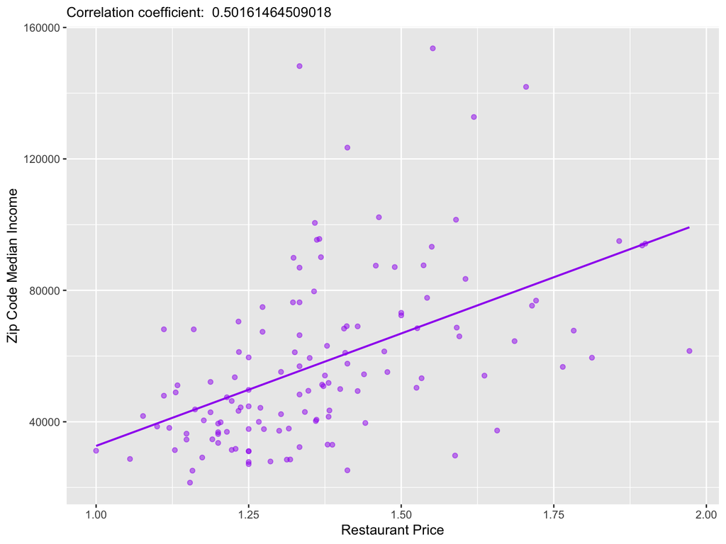

```r
zip_data_sublist <- masterlist %>%
  group_by(zip_code) %>%
  filter(n() >= 10) %>% #10 was chosen somewhat arbitrarily, but excludes zip codes
  #with too few restaurants in them
  summarize(restaurant_price = mean(price, na.rm = TRUE)) %>%
  right_join(harris_data_by_zip, by = "zip_code")

median_price_coeff <- cor(zip_data_sublist$restaurant_price, zip_data_sublist$Median,
    use = "pairwise.complete.obs")
#The 'use' command here omits NA results, I believe)

zip_data_sublist %>%
  ggplot(aes(restaurant_price, y = Median)) +
  geom_point(alpha = 0.5, color = "purple") +
  labs(x = "Restaurant Price", y = "Zip Code Median Income",
       subtitle = paste("Correlation coefficient: ", median_price_coeff)) +
  geom_smooth(method = 'lm', lwd = 0.75, se = FALSE, color = "purple")
```

So with a correlation of right around 0.5, we are looking at a moderately strong correlation. I’m going to conclude that my theory holds!

I want to show this one other way: by mapping median income on one map and median restaurant price on another. To do this, I’ll be using the choroplethrZip package.

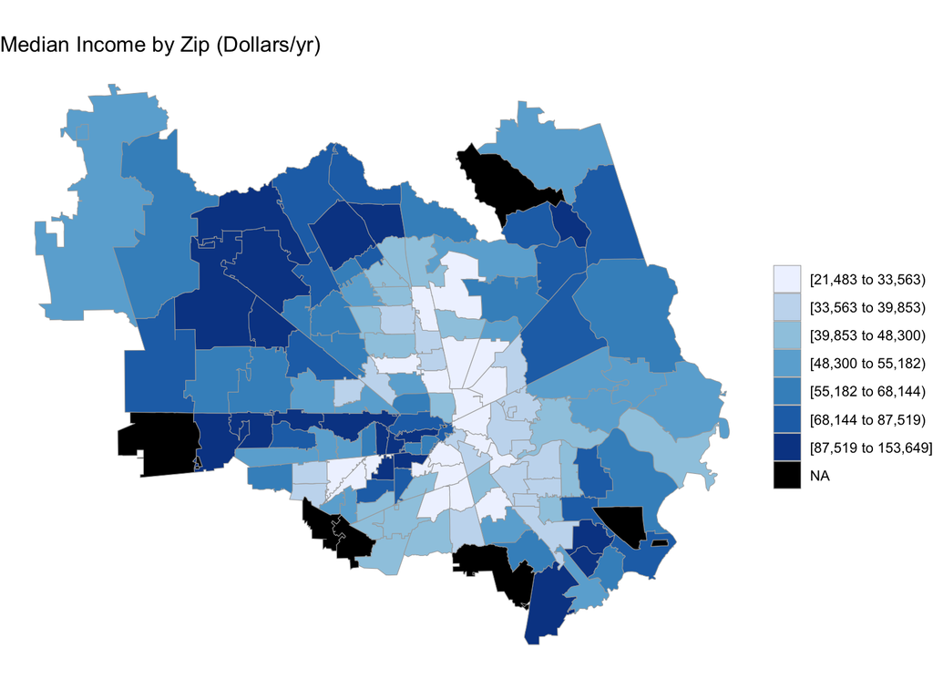

```r
harris_choropleth_data <- harris_data_by_zip #create a new dataframe for this test
harris_choropleth_data$zip_code <- as.character(harris_choropleth_data$zip_code)

#Choroplethr is a bit particular about the format the dataframe argument needs to be
#in, so we have to do some cleaning:
harris_choropleth_data <- harris_choropleth_data %>%
  rename(region = zip_code, value = Median) %>%
  select(region, value)

#Upon googling we find Harris County's unique FIPS code: 48201
zip_choropleth(harris_choropleth_data,
               county_zoom = 48201,
               title = "Median Income by Zip (Dollars/yr)")
```

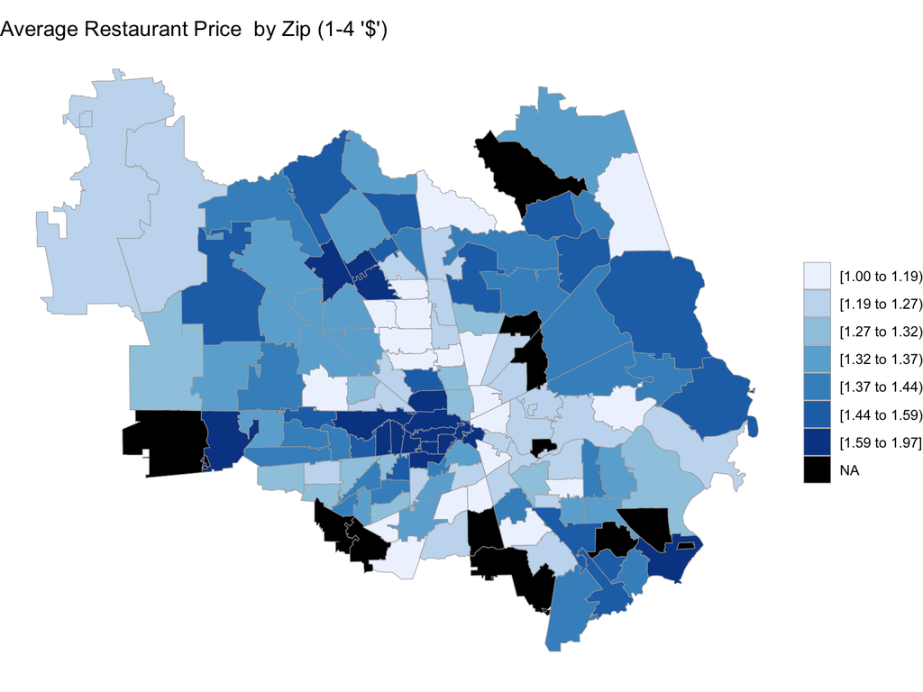

```r
harris_choropleth_data <- zip_data_sublist #overwrite the previous dataframe
harris_choropleth_data$zip_code <- as.character(harris_choropleth_data$zip_code)
harris_choropleth_data <- harris_choropleth_data %>%
  rename(region = zip_code, value = restaurant_price) %>%
  select(region, value)
zip_choropleth(harris_choropleth_data,
               county_zoom = 48201,
               title = "Average Restaurant Price  by Zip (1-4 '$')")
```

Visually, these two maps roughly reflect a correlation in median wealth and restaurant price per zip code.

- Not too surprisingly, restaurants tend to be more expensive in the middle of the city (Many upscale restaurants depend on corporate lunches and dinners for their business).

Crescent around downtown of lower-income zip codes, reflected by lower avg. restaurant price

We can also see that to the west, northwest, and southeast, there are pockets of higher-income zip codes, reflected by higher average restaurant price.

# Final Thoughts

By using an API for our data, the numbers used will update in real time! (r has actually shifted a bit over the course of queries I did)

Previously mentioned problems:

- No way of knowing how yelp selects restaurants to show me, and while almost 6000 restaurants is a lot, it’s nowhere near the total amount in Harris County.
- Certain areas inside the city may be misrepresented, as there are far more restaurants than could have been pulled.

So many more questions to ask!

Overall however, I’m incredibly pleased with how this project turned out. Hope this has been interesting!